# HW9

P. kassraie

December 14, 2016

```r
library(EBImage)
library(cluster)
library(fpc)
library(ggplot2)
library(ggmap)
library(dplyr)
require(highcharter)
library(tidyr)
library(magrittr)
```

## 1. Map Clustering

Reading all the flag images:

```r
#Gathering the data
filenames <- list.files("data/flag", pattern="*.png", full.names=TRUE)
flags <- lapply(filenames,readImage)
```

We calculate the following features for each image:

- Hue Histogram
- Geometrical features of each channel

Hue is the first element in the HSV colorspace, it represents the color (as we see it) of a pixel. Geometrical features are calculated using Computefeatures function in EBImage, which is calculated for all the three channels.

```r
par(mfrow=c(1,1))
Features = matrix(nrow = 196, ncol = 35)


for (i in 1:length(flags)){

  #Color Channels
img = flags[[i]]
imgDm <- dim(img)
imgRGB <- data.frame(
  R = as.vector(img[,,1]),
  G = as.vector(img[,,2]),
  B = as.vector(img[,,3])
  )

# Color histogram
HSV = rgb2hsv(imgRGB$R,imgRGB$G,imgRGB$B)
Hhist = hist(HSV[1,], breaks = seq(0,1,l=21) , plot=F)$counts
Features[i, 1:20] = Hhist


# Geometrical Features
Features[i,21:25] = ifelse(length(computeFeatures.moment(img[,,1]))==0,rep(0,5),computeFeatures.moment(img[,,1]))
Features[i,26:30] = ifelse(length(computeFeatures.moment(img[,,2]))==0,rep(0,5),computeFeatures.moment(img[,,2]))
Features[i,31:35] = ifelse(length(computeFeatures.moment(img[,,3]))==0,rep(0,5),computeFeatures.moment(img[,,3]))
}

# renaming the rows
countries = character()
n=1
for (i in filenames){
  countries[n] = unlist(strsplit(i,split = c("/")))[3]
  countries[n] = unlist(strsplit(countries[n],split = "[.]"))[1]
  n=n+1
}
row.names(Features) = countries
```

Now that we have created the feature vector, let’s cluster the data. But first, we better check whether $k=5$ is a good choise.

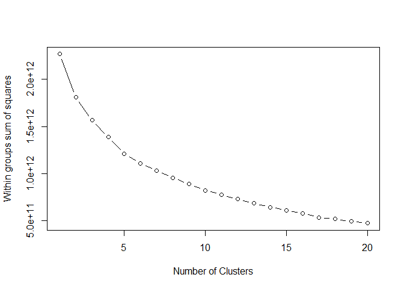

```r
wss <- 1:20
for (i in 1:20) {
  k3 = kmeans(Features,centers = i, nstart = 50)
  wss[i] <- k3$tot.withinss
}

plot(1:20, wss, type="b", xlab="Number of Clusters",
     ylab="Within groups sum of squares")
```

I’ll divide the data to 6 clusters.

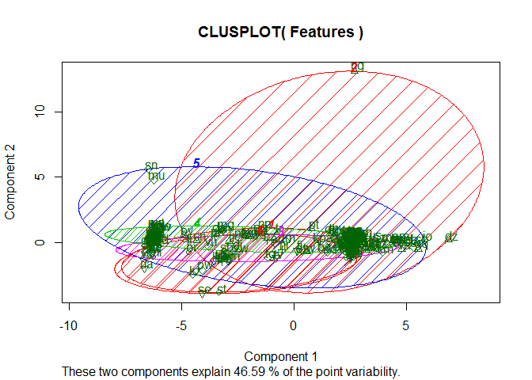

```r
clus = kmeans(Features,centers = 6)
clusplot(Features, clus$cluster, color=TRUE, shade=TRUE,
         labels=2, lines=0)
```

```r
# a new dataframe including the countries and their cluster number

FlagClus <- data.frame(filenames, countries,clus$cluster)
names(FlagClus) <- c("address","Country.Code","Cluster")


hchart(FlagClus, type = "column", x=Country.Code, y=Cluster, group = Cluster) %>%
  hc_add_theme(hc_theme_economist()) %>%
  hc_title(text = "Flags of Each Cluster") %>%
  hc_xAxis(title = list(text = "Country Name")) %>%
  hc_yAxis(title = list(text = "Cluster"))
```

[interactive chart not shown]

In the plot above we see how the clusters are assigned.

```
## [1] "Cluster 1  Includes the Following Flags:"
```

[figure not shown]

```
## [1] "Cluster 2  Includes the Following Flags:"
```

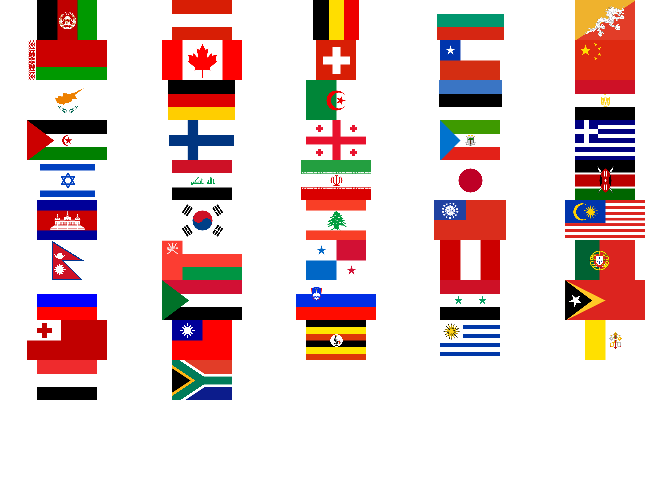

```
## [1] "Cluster 3  Includes the Following Flags:"
```

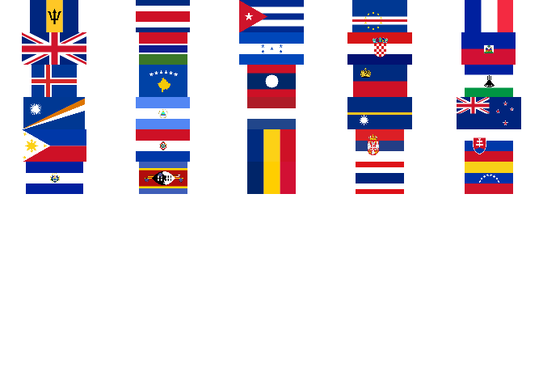

```
## [1] "Cluster 4  Includes the Following Flags:"
```

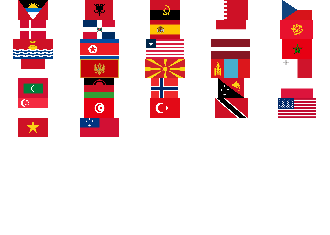

```
## [1] "Cluster 5  Includes the Following Flags:"
```

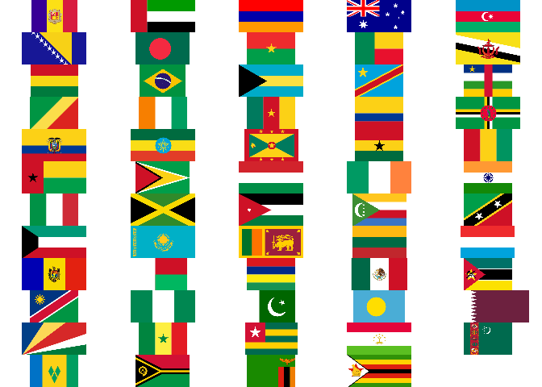

```r
for(i in 1:5){
  temp = filter(FlagClus,Cluster ==i)
  par(mfrow=c(12,5))
  sstring = paste("Cluster",i," Includes the Following Flags:")
  print(sstring)
  for(j in temp$address){
    filename = paste(j)
    pic = readImage(filename)
    display(pic,method = "raster")
  }
}
```

## 2. Countires with a similar flag to iran

In Iran’s cluster, we calculate the euclidean distance of all the countries with iran and choose the top 5.

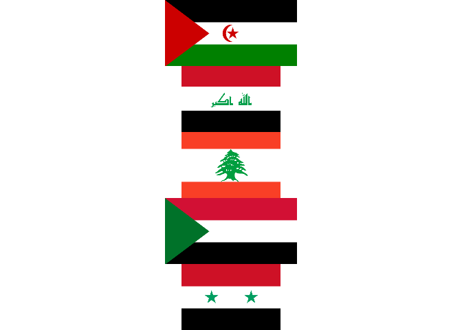

```r
# Selecting the Countries in the cluster including iran
n <- FlagClus$Cluster[which(FlagClus$Country.Code=="ir")]
FlagClus %>% filter(.,Cluster==n) -> temp
row.names(temp) = temp$Country.Code

# Selecting the Feature Matrix for those countries and calcualting the distnce
Features[temp$Country.Code,]->Similars
A = dist(Similars, method = "euclidean", diag = FALSE, upper = FALSE, p = 2)

# Reshaping and sorting
m <- data.frame(t(combn(rownames(Similars),2)), as.numeric(A))
names(m) <- c("c1", "c2", "distance")
m %>% filter(c1=="ir"|c2=="ir")->m
m = m[order(m$distance),]
# the following are chosen after running the kmeans algorithm for several times
Top5 = c('lb','iq','sd','eh','sy')


# Ploting
temp = filter(FlagClus, Country.Code %in% Top5)
par(mfrow=c(5,1))
  for(j in temp$address){
    filename = paste(j)
    pic = readImage(filename)
    display(pic,method = "raster")
  }
```

```r
par(mfrow=c(1,1))
```

## 3. Iran’s Map

```r
#Loading the Data:
load("~/University/5th Semester/Data Analysis/Assignments/HW9/data/iran.RData")
load("~/University/5th Semester/Data Analysis/Assignments/HW9/data/historical_txt_data_26112015.RData")

quakedata$Lat. = as.numeric(as.character(quakedata$Lat.))
quakedata$Long. = as.numeric(as.character(quakedata$Long.))
quakedata$Mag. = as.numeric(as.character(quakedata$Mag.))

quakedata = filter(quakedata, !is.na(quakedata$Lat.))
webdata = readRDS("data/historical_web_data_26112015.rds")
webdata$Latitude = as.integer(webdata$Latitude)
webdata$Longitude = as.integer(webdata$Longitude)

iran = get_map(location = "Iran",zoom=4)
```

[figure not shown]

```r
detachAllPackages <- function() {

  basic.packages <- c("package:stats","package:graphics","package:grDevices","package:utils","package:datasets","package:methods","package:base")

  package.list <- search()[ifelse(unlist(gregexpr("package:",search()))==1,TRUE,FALSE)]

  package.list <- setdiff(package.list,basic.packages)

  if (length(package.list)>0)  for (package in package.list) detach(package, character.only=TRUE)

}

detachAllPackages()

library(dplyr)
library(magrittr)
library(ggmap)
library(ggplot2)

quakedata %>% mutate(lat= round(Lat./0.5)*0.5, lon=round(Long./0.5)*0.5 ) -> quakedata

quakedata %>% group_by(lat,lon) %>% summarise(count = n(),S = sum(Mag.)) -> data

#Number Map
ggmap(iran) +
  geom_point(aes(x = lon ,y = lat, size = count), data = data,alpha = .5, color="indianred")+
  labs(title ="Number of Earthquake")
```

[figure not shown]

```r
#Severity Map
ggmap(iran) +
  geom_point(aes(x = lon ,y = lat ,size = S), data =data,alpha = .5, color="royalblue")+
  labs(title ="Severity of Earthquake")
```

The two worst places are:

[figure not shown]

```r
maxc = max(data$count)
maxs = max(data$S)
datac = filter(data,count==maxc)
ggmap(iran) +
  geom_point(aes(x = lon ,y = lat ,size = S), data =datac,alpha = .5, color="indianred")+
  labs(title ="Number of Earthquake")
```

[figure not shown]

```r
datas = filter(data,S==maxs)
ggmap(iran) +
  geom_point(aes(x = lon ,y = lat ,size = S), data =datas,alpha = .5, color="royalblue")+
  labs(title ="Severity of Earthquake")
```